# 431 Lab 4

Author

Shraddha Dumawat

Published

2024-10-09

## R Setup

```r
library(janitor)
library(Epi)
library(ggdist)
library(knitr)
library(kableExtra)
library(MKinfer)
library(readxl)
library(patchwork)
library(rstanarm)
library(easystats)
library(tidyverse)
library(car)

theme_set(theme_bw())
knitr::opts_chunk$set(comment = NA)

theme_set(theme_bw())
```

## 0.1 Lovedist package

```r
##Loading Lovedist and packages

#| message: false


## should you choose to use the Love-431.R script, source it in here...
`lovedist` <- function(x) {
  tibble::tibble(
    n = length(x),
    miss = sum(is.na(x)),
    mean = mean(x, na.rm = TRUE),
    sd = sd(x, na.rm = TRUE),
    med = median(x, na.rm = TRUE),
    mad = mad(x, na.rm = TRUE),
    min = min(x, na.rm = TRUE),
    q25 = quantile(x, 0.25, na.rm = TRUE),
    q75 = quantile(x, 0.75, na.rm = TRUE),
    max = max(x, na.rm = TRUE),
  )
}

`twobytwo` <-
  function(a,b,c,d,
           namer1 = "Row1", namer2 = "Row2",
           namec1 = "Col1", namec2 = "Col2",
           conf.level = 0.95)
    # build 2 by 2 table and run Epi library's twoby2 command to summarize
    # from the row-by-row counts in a cross-tab
    # upper left cell is a, upper right is b,
    # lower left is c, lower right is d
    # names are then given in order down the rows then across the columns
    # use standard epidemiological format:
    # outcomes in columns, treatments in rows
  {
    .Table <- matrix(c(a, b, c, d), 2, 2, byrow=T,
                     dimnames=list(c(namer1, namer2),
                                   c(namec1, namec2)))
    Epi::twoby2(.Table, alpha = 1 - conf.level)
  }


`saifs_ci` <-
  function(x, n, conf.level=0.95, dig=3)
  {
    p.sample <- round(x/n, digits=dig)

    p1 <- x / (n+1)
    p2 <- (x+1) / (n+1)

    var1 <- (p1*(1-p1))/n
    se1 <- sqrt(var1)
    var2 <- (p2*(1-p2))/n
    se2 <- sqrt(var2)

    lowq = (1 - conf.level)/2
    tcut <- qt(lowq, df=n-1, lower.tail=FALSE)

    lower.bound <- round(p1 - tcut*se1, digits=dig)
    upper.bound <- round(p2 + tcut*se2, digits=dig)
    tibble(
      sample_x = x,
      sample_n = n,
      sample_p = p.sample,
      lower = lower.bound,
      upper = upper.bound,

      conf_level = conf.level
    )
  }
```

# 1 Task 1

## 1.1 Ingesting the Data

```r
dm <- read_excel("C:/Users/Shraddha Dumawat/Downloads/lab4-task1.xlsx") |>
  janitor::clean_names()
```

```r
dm
```

```
# A tibble: 235 × 3
   subject intervention postop4
   <chr>   <chr>        <chr>
 1 LG-001  licorice     some_pain
 2 LG-002  licorice     no_pain
 3 LG-003  sugar        no_pain
 4 LG-004  licorice     <NA>
 5 LG-005  sugar        no_pain
 6 LG-006  sugar        some_pain
 7 LG-007  licorice     no_pain
 8 LG-008  licorice     no_pain
 9 LG-009  sugar        no_pain
10 LG-010  sugar        no_pain
# ℹ 225 more rows
```

## 1.2 Comparing Rates

```r
dm <- dm %>% drop_na(intervention,postop4)
dm |> tabyl(intervention, postop4)
```

```
 intervention no_pain some_pain
     licorice      93        24
        sugar      64        52
```

```r
twoby2(table(dm$intervention, dm$postop4))
```

```
2 by 2 table analysis:
------------------------------------------------------
Outcome   : no_pain
Comparing : licorice vs. sugar

         no_pain some_pain    P(no_pain) 95% conf. interval
licorice      93        24        0.7949    0.7121   0.8585
sugar         64        52        0.5517    0.4605   0.6396

                                   95% conf. interval
             Relative Risk: 1.4407    1.1937   1.7389
         Sample Odds Ratio: 3.1484    1.7645   5.6177
Conditional MLE Odds Ratio: 3.1324    1.7021   5.8884
    Probability difference: 0.2431    0.1233   0.3537

             Exact P-value: 0.0001
        Asymptotic P-value: 0.0001
------------------------------------------------------
```

# 2 Task 2

In this study comparing Licorice and Sugar for pain relief, 79.5% of the 117 participants who gargled with Licorice reported no sore throat pain 4 hours after surgery, while only 55.2% of the 116 participants who used Sugar reported the same. The **odds ratio** of 3.14 (greater than 1), suggests that the odds of experiencing no pain were over three times higher for those using Licorice than for those using Sugar. The **relative risk** is 1.44 indicates that the likelihood of being pain-free is higher in the Licorice group. The **risk difference** of 0.2432 (79.5% - 55.2%) also suggests a greater probability of improvement with Licorice. The **95% confidence interval** for the probability of no pain with Licorice is [0.7121, 0.8585], and for Sugar, it’s [0.4605, 0.6396]. Since these intervals don’t overlap, it suggests a noticeable difference in the likelihood of pain relief between the Licorice and Sugar groups, 4 hours after surgery.

The study design described in the publication indicates that ‘Patients were **randomly** assigned to gargle…’ and that ‘Sore throat and postextubation coughing […] were measured using an … investigator **blinded** to treatment.’ Reflecting on Spiegelhalter’s *The Art of Statistics*, randomization and blinding are crucial for establishing causation in a trial. This study’s use of randomization ensures that treatment groups are comparable, while blinding minimizes bias in reporting outcomes, making the results more reliable and robust.

# 3 Task 3

## 3.1 Ingesting the data

```r
dm2 <- read_excel("C:/Users/Shraddha Dumawat/OneDrive/Desktop/lab4-task3.xlsx") |>
  janitor::clean_names()
```

```r
dm2
```

```
# A tibble: 300 × 6
   patientid group_rx partner            age sbp_baseline sbp_follow
   <chr>        <dbl> <chr>            <dbl>        <dbl>      <dbl>
 1 P001             3 partner with htn    61          142        134
 2 P002             3 partner no htn      60          148        157
 3 P003             1 partner with htn    57          150        125
 4 P004             1 partner no htn      64          154        132
 5 P005             3 partner with htn    57          139        136
 6 P006             1 partner with htn    57          163        133
 7 P007             2 partner no htn      63          152        125
 8 P008             2 partner no htn      60          135        123
 9 P009             1 partner with htn    63          170        138
10 P010             3 partner no htn      64          131        124
# ℹ 290 more rows
```

```r
dm2$group_f <- factor(dm2$group_rx,
                       levels = c(1, 2, 3),
                       labels = c("Group_A", "Group_B", "Group_C"))
dm2
```

```
# A tibble: 300 × 7
   patientid group_rx partner            age sbp_baseline sbp_follow group_f
   <chr>        <dbl> <chr>            <dbl>        <dbl>      <dbl> <fct>
 1 P001             3 partner with htn    61          142        134 Group_C
 2 P002             3 partner no htn      60          148        157 Group_C
 3 P003             1 partner with htn    57          150        125 Group_A
 4 P004             1 partner no htn      64          154        132 Group_A
 5 P005             3 partner with htn    57          139        136 Group_C
 6 P006             1 partner with htn    57          163        133 Group_A
 7 P007             2 partner no htn      63          152        125 Group_B
 8 P008             2 partner no htn      60          135        123 Group_B
 9 P009             1 partner with htn    63          170        138 Group_A
10 P010             3 partner no htn      64          131        124 Group_C
# ℹ 290 more rows
```

### 3.1.1 Numerical summary

```r
dm2 |>
  reframe(lovedist(sbp_follow), .by = group_f) |>
  kable(digits = 2)
```

| group_f | n | miss | mean | sd | med | mad | min | q25 | q75 | max |
| --- | --- | --- | --- | --- | --- | --- | --- | --- | --- | --- |
| Group_C | 100 | 0 | 144.95 | 9.26 | 145.5 | 11.12 | 124 | 138 | 152.00 | 163 |
| Group_A | 100 | 0 | 132.45 | 10.23 | 133.0 | 10.38 | 104 | 125 | 139.00 | 153 |
| Group_B | 100 | 0 | 129.24 | 8.21 | 128.0 | 7.41 | 104 | 123 | 134.25 | 152 |

### 3.1.2 Rain-cloud plot

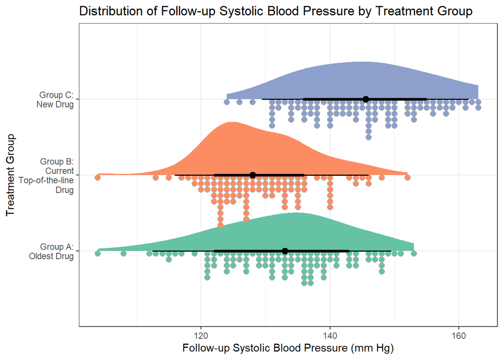

```r
ggplot(dm2, aes(y = group_f, x = sbp_follow, fill = group_f)) +
  stat_slab(aes(thickness = after_stat(pdf * n)), scale = 0.7) +
  stat_dotsinterval(side = "bottom", scale = 0.7, slab_linewidth = NA) +
  scale_fill_brewer(palette = "Set2") +
  guides(fill = "none") +
  scale_y_discrete(labels = c(
    "Group_A" = "Group A:\nOldest Drug",
    "Group_B" = "Group B:\nCurrent\nTop-of-the-line\nDrug",
    "Group_C" = "Group C:\nNew Drug"
  )) +
  labs(
    title = "Distribution of Follow-up Systolic Blood Pressure by Treatment Group",
    x = "Follow-up Systolic Blood Pressure (mm Hg)",
    y = "Treatment Group"
  )
```

### 3.1.3 Violin-Boxplot

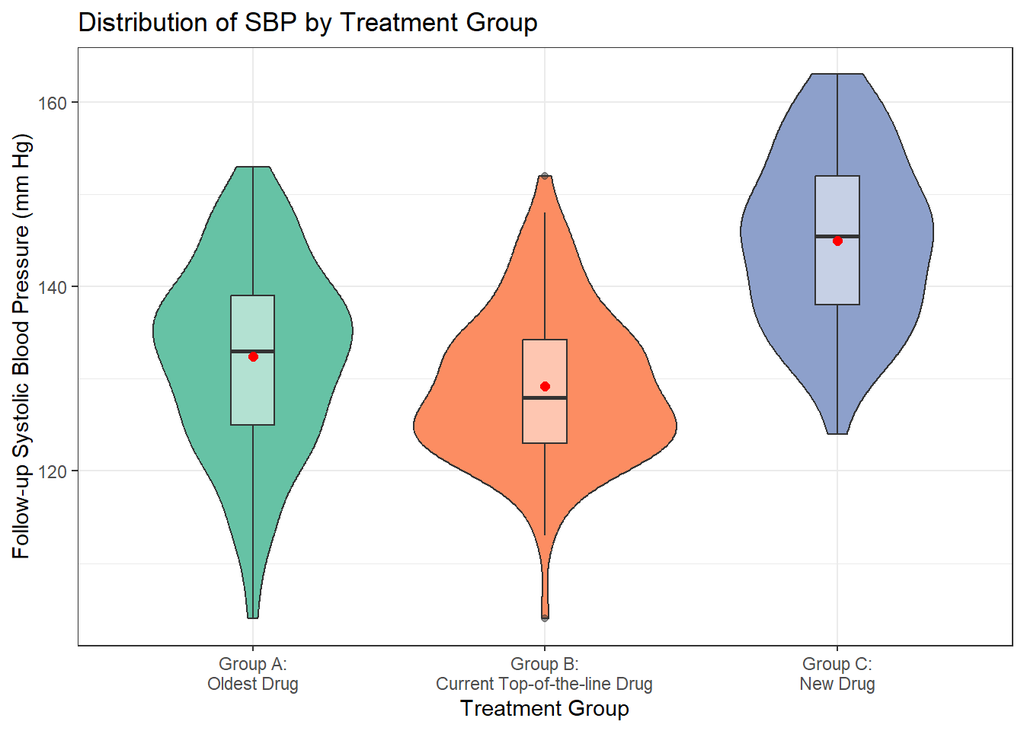

```r
ggplot(dm2, aes(x = group_f, y = sbp_follow)) +
  geom_violin(aes(fill = group_f)) +
  geom_boxplot(width = 0.15, alpha = 0.5) +
  stat_summary(geom = "point", fun = "mean", col = "red", size = 2) +
  scale_fill_brewer(palette = "Set2") +
  guides(fill = "none") +
  scale_x_discrete(labels = c(
    "Group_A" = "Group A:\nOldest Drug",
    "Group_B" = "Group B:\nCurrent Top-of-the-line Drug",
    "Group_C" = "Group C:\nNew Drug"
  )) +
  labs(
    title = "Distribution of SBP by Treatment Group",
    x = "Treatment Group",
    y = "Follow-up Systolic Blood Pressure (mm Hg)"
  )
```

## 3.2 QQ Plot

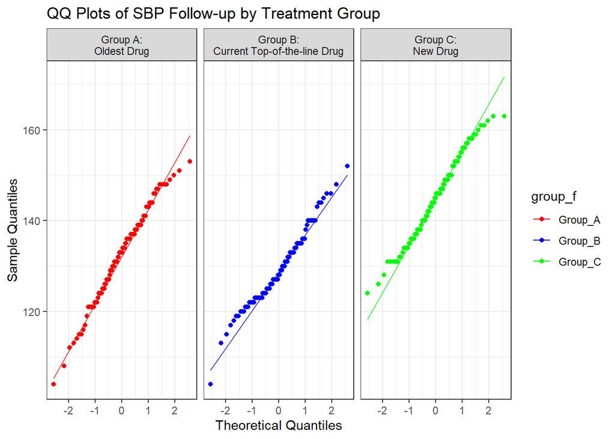

```r
ggplot(dm2, aes(sample = sbp_follow, color = group_f)) +
  stat_qq() +
  stat_qq_line() +
  facet_wrap(~ group_f, labeller = as_labeller(c(
    "Group_A" = "Group A:\nOldest Drug",
    "Group_B" = "Group B:\nCurrent Top-of-the-line Drug",
    "Group_C" = "Group C:\nNew Drug"
  ))) +
  scale_color_manual(values = c("red", "blue", "green")) +
  labs(
    title = "QQ Plots of SBP Follow-up by Treatment Group",
    x = "Theoretical Quantiles",
    y = "Sample Quantiles"
  )
```

### 3.2.1 Analysis of the results

# 4 Task 4

```r
model_one <- lm(sbp_follow ~ group_f, data = dm2)

model_parameters(model_one, ci = 0.90)
```

```
Parameter         | Coefficient |   SE |           90% CI | t(297) |      p
---------------------------------------------------------------------------
(Intercept)       |      132.45 | 0.93 | [130.92, 133.98] | 142.89 | < .001
group f [Group_B] |       -3.21 | 1.31 | [ -5.37,  -1.05] |  -2.45 | 0.015
group f [Group_C] |       12.50 | 1.31 | [ 10.34,  14.66] |   9.54 | < .001
```

```
Uncertainty intervals (equal-tailed) and p-values (two-tailed) computed
  using a Wald t-distribution approximation.
```

```r
tukey1 <- estimate_contrasts(model_one, contrast = "group_f", ci = 0.90, p_adjust = "tukey")

tukey1 |> kable(digits = 2)
```

| Level1 | Level2 | Difference | CI_low | CI_high | SE | df | t | p |
| --- | --- | --- | --- | --- | --- | --- | --- | --- |
| Group_A | Group_B | 3.21 | 0.51 | 5.91 | 1.31 | 297 | 2.45 | 0.04 |
| Group_A | Group_C | -12.50 | -15.20 | -9.80 | 1.31 | 297 | -9.54 | 0.00 |
| Group_B | Group_C | -15.71 | -18.41 | -13.01 | 1.31 | 297 | -11.98 | 0.00 |

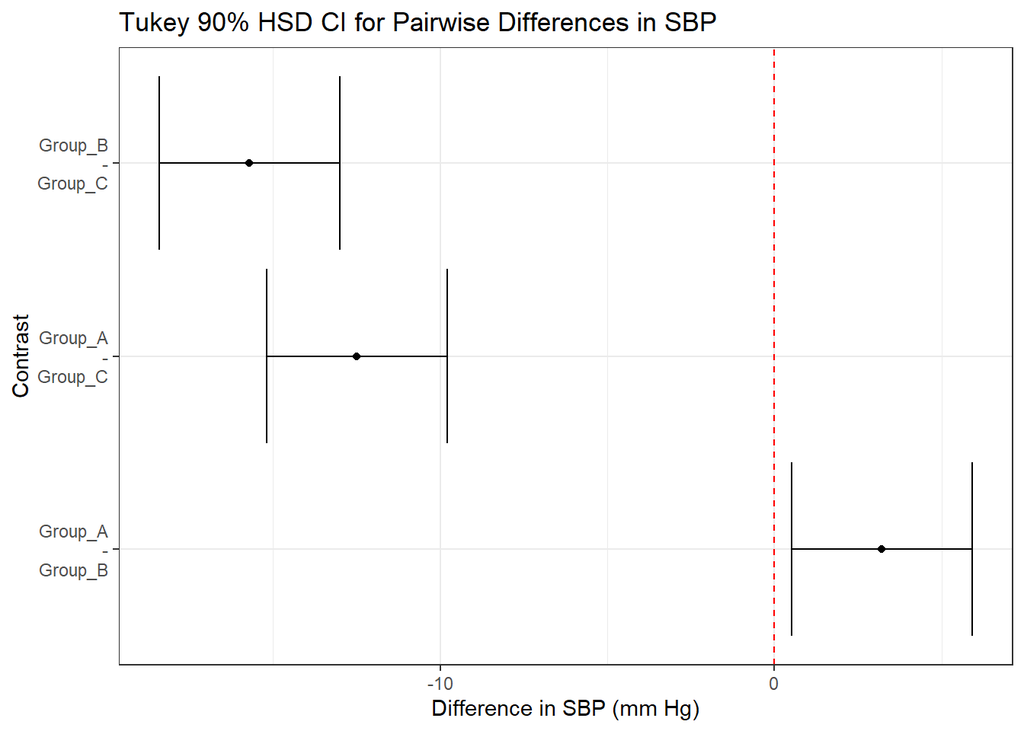

```r
tukey1_tib <- tibble(tukey1) |>
  mutate(contr = str_c(Level1, "\n", "-", "\n", Level2))

ggplot(tukey1_tib, aes(y = contr, x = Difference)) +
  geom_point() +
  geom_errorbar(aes(xmin = CI_low, xmax = CI_high)) +
  geom_vline(xintercept = 0, col = "red", lty = "dashed") +
  labs(
    title = "Tukey 90% HSD CI for Pairwise Differences in SBP",
    y = "Contrast",
    x = "Difference in SBP (mm Hg)"
  )
```

## 4.1 Analysis

Overall :

Through our observation, the linear model suggests that Group B has a lower average SBP than group A, with the 90% Confidence interval being [ -5.37, -1.05]. This Indicates that Group B subjects had lower follow up SBP compared to group A. The small p value further strengthens the understanding. Group C on the other hand, indicated a higher follow up SBP as compared to Group A, considering a 12.50 mm Hg higher average in SBP. The 90% Confidence interval of [10.34, 14.66] along with the small p-value of <0.001 further strengthen the argument. Overall, Group C results in higher values while Group B achieves reduction in SBP as compared to Group A.

Pairwise :

Observing Tukey’s HSD method for pairwise comparisons , we can understand how each group compares with the other. The plot also further expands on this. We can observe that in Group A vs Group B, the difference is 3.21 mm Hg, with Group B being lower and the 90% confidence interval is [0.51, 5.91] (does not cross O), this indicates that a reduction in SBP is observed in Group B as compared to group A. However, while comparing the other two groups, we see that in Group A vs Group C, the difference is that of - 12.50, with group C being higher, and the Confidence interval is [-15.20, -9.80], which does not cross 0, suggesting that Group C subjects experienced a higher follow up SBP as opposed to group A. Finally, looking at Group B vs Group C, we again see a similar patter, wherein the difference of -15.71 mm Hg with Group C being higher and a CI of [-18.41, -13.01] suggest that Group C showed higher SBP levels as compared to group C. These results point towards the possibility of Group C (new drug) might not be as effective as the current top-of-the-line drug (group B) and the oldest drug (group A).

# 5 Task 5

One particularly interesting insight from the book R for Data Science is its strong emphasis on visualization as a crucial tool for effective communication. The techniques discussed, especially in Chapter 11, provided me with valuable codes and practices for exploring data more deeply. These tools help uncover patterns and insights and identify anomalies before delving into more complex modeling.

An important aspect briefly covered in the chapter was the consideration of visualizations that can be interpreted by people with color blindness. The book notes, *“…The two plots below look similar, but there is enough difference in the shades of red and green that the dots on the right can be distinguished even by people with red-green color blindness.”* This highlights the importance of accessibility and fairness in scientific communication.

The systematic approach of building complex plots by layering elements such as data, geoms, and scales also helped me understand the intricate functions of ggplot2 and, eventually, the underlying structure of the data. This approach not only simplifies the process of creating effective visualizations but also enhances the ability to communicate insights clearly.